# chapter3

RK

13 November 2018

## Chapter 3

The original dataset describes student achievement in secondary education of two Portuguese schools. For present purposes, I have combined two datasets (performance in mathematics and Portuguese) into one dataset, which I analyse below.

The 35 variables in our dataset alc.csv are listed below.

```
##  [1] "school"     "sex"        "age"        "address"    "famsize"
##  [6] "Pstatus"    "Medu"       "Fedu"       "Mjob"       "Fjob"
## [11] "reason"     "nursery"    "internet"   "guardian"   "traveltime"
## [16] "studytime"  "failures"   "schoolsup"  "famsup"     "paid"
## [21] "activities" "higher"     "romantic"   "famrel"     "freetime"
## [26] "goout"      "Dalc"       "Walc"       "health"     "absences"
## [31] "G1"         "G2"         "G3"         "alc_use"    "high_use"
```

```
## [1] 382  35
```

In this exercise I wish to analyse how several variables relate to high use (`high_use`) of alcohol. My hypotheses are that

1. `failures` increase the odds for high use of alcohol. Note that `failures` here is the number of past class failures (numeric: n if 1<=n<3, else 4).
2. `absences` increase the odds for high use of alcohol. The absences variable describes the number of school absences (numeric: from 0 to 93).
3. `sexM` (being male) increase the odds for high use of alcohol.
4. `age` (aging) increases the odds for high use of alcohol.

Before fitting a logistic regression model to the data, let’s graphically and numerically explore these variables in relation to `high_use`. There are, of course, many ways to explore these relations, but I chose to use crosstabulations and boxplots here. Here’s what they look like:

```
## # A tibble: 4 x 4
## # Groups:   sex [?]
##   sex   high_use count mean_failures
##   <fct> <lgl>    <int>         <dbl>
## 1 F     FALSE      156         0.115
## 2 F     TRUE        42         0.286
## 3 M     FALSE      112         0.179
## 4 M     TRUE        72         0.375
```

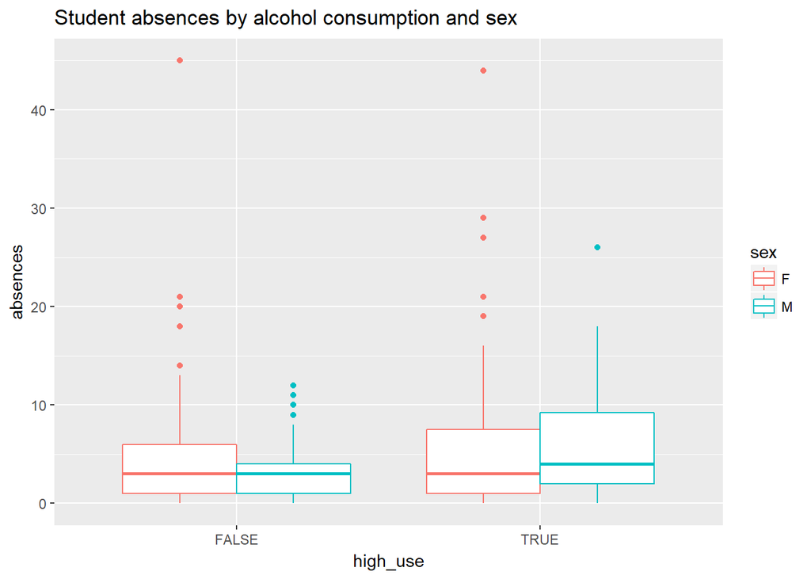

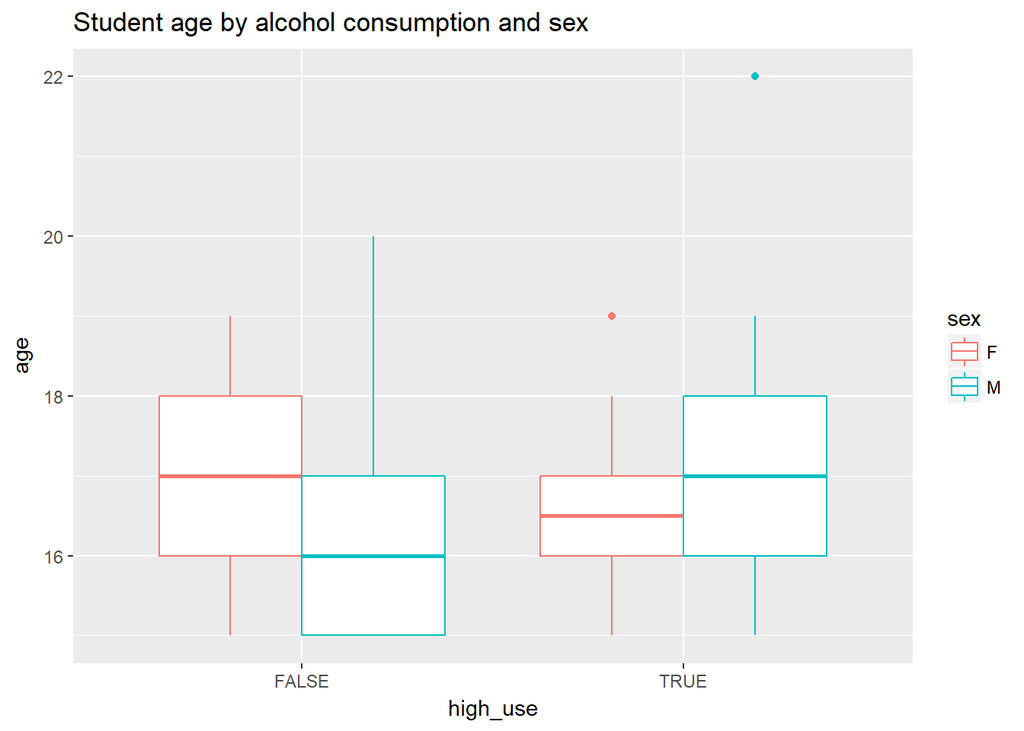

```
## # A tibble: 4 x 3
## # Groups:   sex [?]
##   sex   high_use count
##   <fct> <lgl>    <int>
## 1 F     FALSE      156
## 2 F     TRUE        42
## 3 M     FALSE      112
## 4 M     TRUE        72
```

Now, lets see what the logistic regression model and odds ratios (with confidence intervals) look like.

```
##
## Call:
## glm(formula = high_use ~ failures + absences + sex + age, family = "binomial",
##     data = dat)
##
## Deviance Residuals:
##     Min       1Q   Median       3Q      Max
## -2.2191  -0.8316  -0.6178   1.0504   2.1065
##
## Coefficients:
##             Estimate Std. Error z value Pr(>|z|)
## (Intercept) -4.15109    1.73220  -2.396   0.0166 *
## failures     0.40692    0.19443   2.093   0.0364 *
## absences     0.09039    0.02305   3.921 8.80e-05 ***
## sexM         0.94825    0.24256   3.909 9.26e-05 ***
## age          0.13650    0.10384   1.315   0.1887
## ---
## Signif. codes:  0 '***' 0.001 '**' 0.01 '*' 0.05 '.' 0.1 ' ' 1
##
## (Dispersion parameter for binomial family taken to be 1)
##
##     Null deviance: 465.68  on 381  degrees of freedom
## Residual deviance: 422.66  on 377  degrees of freedom
## AIC: 432.66
##
## Number of Fisher Scoring iterations: 4
```

```
##                     OR        2.5 %    97.5 %
## (Intercept) 0.01574723 0.0005033679 0.4540441
## failures    1.50218218 1.0261944393 2.2126966
## absences    1.09459580 1.0484251930 1.1477452
## sexM        2.58118308 1.6134349856 4.1835173
## age         1.14625201 0.9359125689 1.4073438
```

Again, I will break the analysis down variable by variable:

1. `failures` The Odds Ratio (OR) for failures is about 1.5. This is not a very large effect size, even if it is below the level of statistical significance (p = 0.0364).
2. `absences` OR for absences is ~1.1. Again, this isn’t a very large Odds Ratio, although it is statistically significant.
3. `sexM` OR for sex (male) is ~2.6. Sex (i.e., being male) seems to be a very strong predictor for high use of alcohol. It is also, unsurprisingly, highly statistically significant (p = 9.26e-05).
4. `age`OR for age is ~1.15. Note, however, that hte 95 % confidence intervals include 1. This means that the effect can go either way (age might increase or decrease the odds for high use). Basically, what this means is that `age` isn’t much use in modeling high use of alcohol consumption on this model.

Therefore I chose to drop `age` from the logistic regression model model. Here’s the model I will use in the rest of these exercises:

```
##
## Call:
## glm(formula = high_use ~ failures + absences + sex, family = "binomial",
##     data = dat)
##
## Deviance Residuals:
##     Min       1Q   Median       3Q      Max
## -2.1855  -0.8371  -0.6000   1.1020   2.0209
##
## Coefficients:
##             Estimate Std. Error z value Pr(>|z|)
## (Intercept) -1.90297    0.22626  -8.411  < 2e-16 ***
## failures     0.45082    0.18992   2.374 0.017611 *
## absences     0.09322    0.02295   4.063 4.85e-05 ***
## sexM         0.94117    0.24200   3.889 0.000101 ***
## ---
## Signif. codes:  0 '***' 0.001 '**' 0.01 '*' 0.05 '.' 0.1 ' ' 1
##
## (Dispersion parameter for binomial family taken to be 1)
##
##     Null deviance: 465.68  on 381  degrees of freedom
## Residual deviance: 424.40  on 378  degrees of freedom
## AIC: 432.4
##
## Number of Fisher Scoring iterations: 4
```

```
##                   OR2      2.5 %   97.5 %
## (Intercept) 0.1491257 0.09395441 0.228611
## failures    1.5695984 1.08339644 2.294737
## absences    1.0977032 1.05169654 1.150848
## sexM        2.5629682 1.60381392 4.149405
```

I then use the model above to predict probabilities to explore the predictive power of my model. Basically, I use the model to predict the data the model is based on. In this analysis, when probability > 0.5 we predict `high_use` and in other cases low use of alcohol.

Here I analyse the predictive power:

```
##         prediction
## high_use FALSE TRUE Sum
##    FALSE   259    9 268
##    TRUE     84   30 114
##    Sum     343   39 382
```

```
##         prediction
## high_use      FALSE       TRUE        Sum
##    FALSE 0.67801047 0.02356021 0.70157068
##    TRUE  0.21989529 0.07853403 0.29842932
##    Sum   0.89790576 0.10209424 1.00000000
```

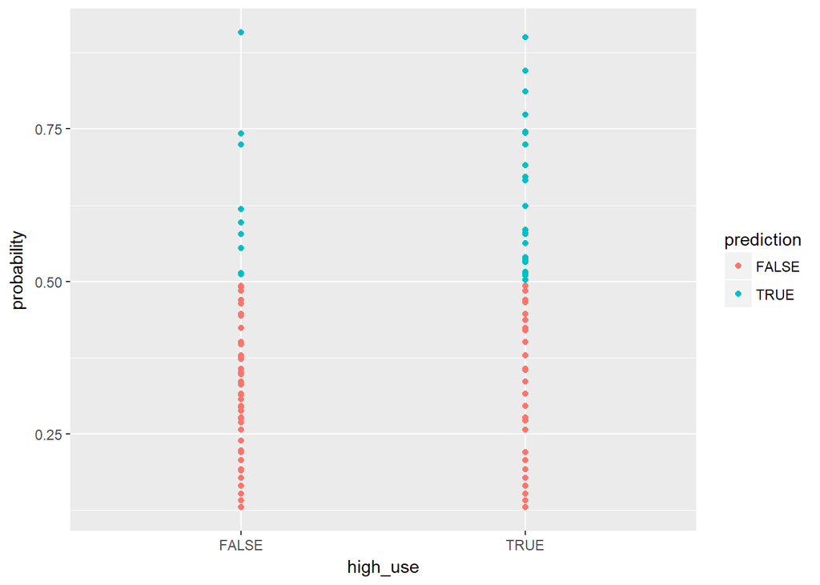

```
## [1] 0.2434555
```

In my opinion, this isn’t a therefore spectacularly good model at predicting data. Imagine, for instance, that we were interested in using the model to design interventions and thus would use it to spot potential high users of alcohol. From 39 guesses, we would guess 30 correct and 9 wrong.

However, the model is better than a simple guessing strategy. Imagine, for instance, if we just guessed that users were low consumers of alcohol:

```
## [1] 0.2984293
```

In this case, we would get around 30 % of our guesses wrong. So yes, my model is better than a simple guessing strategy, but not very much… (I wonder how good a simple one-dimensional model would be with only sex as a predictor!)

BONUS: Finally, I’ll perform a 10-fold cross-validation by bootstrapping the model. I set the random seed at 1 for this one (meaning that I’ll always get the same result).

```
## [1] 0.2486911
```